# Working with Paycheck Protection Program data in R

Conor Tompkins

2020-07-08

In this post, I walk through the process of reading in the data from the Paycheck Protection Program, and show some basic analyses that can be done.

Load packages and set up environment:

```r
library(tidyverse)
library(sf)
library(tigris)
library(lubridate)
library(janitor)
library(hrbrthemes)

theme_set(theme_ipsum(base_size = 18))

options(scipen = 999, digits = 4)
```

## Load and clean data

The data is available at this site: https://home.treasury.gov/policy-issues/cares-act/assistance-for-small-businesses/sba-paycheck-protection-program-loan-level-data

The data exists in numerous CSV files, separated by state and sometimes loan amount.

This code chunk identifies all the CSV files in the folder, reads them in, and combines them.

```r
path <- "data/ppp"

#find all files in the folder that end in .csv
ppp <- list.files(path, full.names = TRUE, recursive = TRUE) %>%
  keep(str_detect(., ".csv$")) %>%
  #read each file with read_csv and combine them
  set_names() %>%
  map_dfr(read_csv, col_types = cols(.default = "c"), .id = "file_name") %>%
  clean_names()

glimpse(ppp)
```

```
## Rows: 4,885,388
## Columns: 18
## $ file_name      <chr> "data/ppp/All Data by State/150k plus/foia_150k_plus.c…
## $ loan_range     <chr> "a $5-10 million", "a $5-10 million", "a $5-10 million…
## $ business_name  <chr> "ARCTIC SLOPE NATIVE ASSOCIATION, LTD.", "CRUZ CONSTRU…
## $ address        <chr> "7000 Uula St", "7000 East Palmer Wasilla Hwy", "2606 …
## $ city           <chr> "BARROW", "PALMER", "ANCHORAGE", "ANCHORAGE", "PALMER"…
## $ state          <chr> "AK", "AK", "AK", "AK", "AK", "AK", "AK", "AK", "AK", …
## $ zip            <chr> "99723", "99645", "99503", "99515", "99645", "99503", …
## $ naics_code     <chr> "813920", "238190", "722310", "621111", "517311", "541…
## $ business_type  <chr> "Non-Profit Organization", "Subchapter S Corporation",…
## $ race_ethnicity <chr> "Unanswered", "Unanswered", "Unanswered", "Unanswered"…
## $ gender         <chr> "Unanswered", "Unanswered", "Unanswered", "Unanswered"…
## $ veteran        <chr> "Unanswered", "Unanswered", "Unanswered", "Unanswered"…
## $ non_profit     <chr> "Y", NA, NA, NA, NA, NA, NA, NA, NA, NA, NA, NA, NA, N…
## $ jobs_retained  <chr> "295", "215", "367", "0", "267", "231", "298", "439", …
## $ date_approved  <chr> "04/14/2020", "04/15/2020", "04/11/2020", "04/29/2020"…
## $ lender         <chr> "National Cooperative Bank, National Association", "Fi…
## $ cd             <chr> "AK - 00", "AK - 00", "AK - 00", "AK - 00", "AK - 00",…
## $ loan_amount    <chr> NA, NA, NA, NA, NA, NA, NA, NA, NA, NA, NA, NA, NA, NA…
```

This changes how the columns are interpreted, and separates the congressional district column into state and district. If the `district` value is blank, I replace it with `NA`.

```r
ppp <- ppp %>%
  mutate(jobs_retained = as.numeric(jobs_retained),
         date_approved = mdy(date_approved),
         loan_amount = as.numeric(loan_amount),
         file_name = str_remove(file_name, path)) %>%
  #separate cd column into state_2 and district
  separate(cd, into = c("state_2", "district"), remove = FALSE) %>%
  #when district is blank, replace with NA
  mutate(district = case_when(district == "" ~ NA_character_,
                          district != "" ~ district)) %>%
  mutate(loan_range = str_trim(loan_range),
         loan_range = str_sub(loan_range, 3, str_length(loan_range)),
         loan_range = case_when(!str_detect(file_name, "150k plus") ~ "Under $150k",
                                TRUE ~ loan_range))
```

There are cases where the value in the `state` column doesn’t match the state embedded in the congressional district `cd` column.

```r
#preview data where state doesn't match congressional district
ppp %>%
  filter(file_name == "/All Data by State/Virginia/foia_up_to_150k_VA.csv") %>%
  count(file_name, state, cd, state_2, sort = TRUE) %>%
  mutate(flag_match = state == state_2) %>%
  filter(flag_match == FALSE) %>%
  slice(1:5)
```

```
## # A tibble: 5 x 6
##   file_name                                state cd     state_2     n flag_match
##   <chr>                                    <chr> <chr>  <chr>   <int> <lgl>
## 1 /All Data by State/Virginia/foia_up_to_… VA    GA - … GA          1 FALSE
## 2 /All Data by State/Virginia/foia_up_to_… VA    MD - … MD          1 FALSE
## 3 /All Data by State/Virginia/foia_up_to_… VA    NC - … NC          1 FALSE
## 4 /All Data by State/Virginia/foia_up_to_… VA    PA - … PA          1 FALSE
## 5 /All Data by State/Virginia/foia_up_to_… VA    WV - … WV          1 FALSE
```

There are only 414 rows where this occurs, and it is less than 1% of the dataset.

```r
#summarize cases where mismatch occurs
ppp %>%
  mutate(flag_match = state == state_2) %>%
  count(flag_match) %>%
  mutate(pct_mismatch = n / sum(n),
         pct_mismatch = round(pct_mismatch, 4)) %>%
  filter(flag_match == FALSE) %>%
  arrange(-pct_mismatch)
```

```
## # A tibble: 1 x 3
##   flag_match     n pct_mismatch
##   <lgl>      <int>        <dbl>
## 1 FALSE        414       0.0001
```

Most of these bad rows are in the `foia_up_to_150k_other.csv` and `foia_150k_plus.csv` files.

```r
ppp %>%
  mutate(flag_match = state == state_2) %>%
  count(file_name, flag_match) %>%
  group_by(file_name) %>%
  mutate(pct_mismatch = n / sum(n),
         pct_mismatch = round(pct_mismatch, 4)) %>%
  ungroup() %>%
  filter(flag_match == FALSE) %>%
  arrange(-pct_mismatch) %>%
  slice(1:5)
```

```
## # A tibble: 5 x 4
##   file_name                                        flag_match     n pct_mismatch
##   <chr>                                            <lgl>      <int>        <dbl>
## 1 /All Data by State/Other/foia_up_to_150k_other.… FALSE        195     0.995
## 2 /All Data by State/Virgin Islands/foia_up_to_15… FALSE          1     0.000600
## 3 /All Data by State/150k plus/foia_150k_plus.csv  FALSE        112     0.0002
## 4 /All Data by State/Arkansas/foia_up_to_150k_AR.… FALSE          8     0.0002
## 5 /All Data by State/Kentucky/foia_up_to_150k_KY.… FALSE         10     0.0002
```

I filter out the rows where the state doesn’t match the congressional district.

```r
ppp <- ppp %>%
  filter(state == state_2)
```

This shows that there are some negative values in `loan_amount`. I filter out those values.

```r
ppp %>%
  mutate(loan_type = loan_amount > 0) %>%
  count(loan_type)
```

```
## # A tibble: 3 x 2
##   loan_type       n
##   <lgl>       <int>
## 1 FALSE          27
## 2 TRUE      4223841
## 3 NA         661106
```

```r
ppp <- ppp %>%
  filter(loan_amount > 0 | is.na(loan_amount))
```

## Analysis

### Loan amount

The first step is to split the data into 2 buckets. For loans above $150k, the SBA binned the loan amount instead of reporting the actual value.

```r
ppp_under_150 <- ppp %>%
  filter(!str_detect(file_name, "150k plus"))

ppp_over_150 <- ppp %>%
  filter(str_detect(file_name, "150k plus")) %>%
  mutate(loan_range = fct_infreq(loan_range))
```

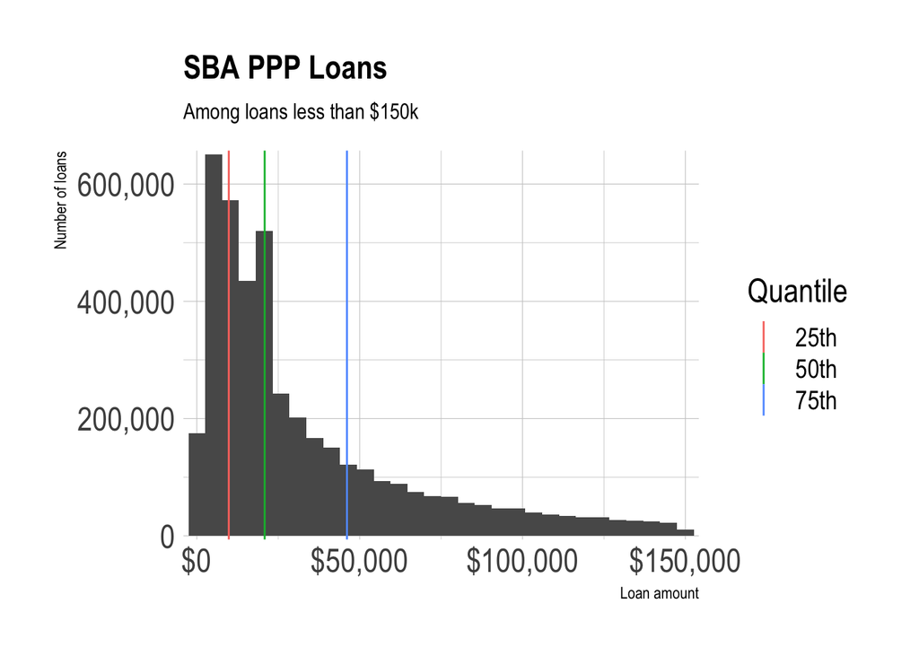

```r
quantiles <- ppp_under_150 %>%
  summarize(quantiles = quantile(loan_amount, probs = c(.25, .50, .75)),
            probability = c("25th", "50th", "75th")) %>%
  mutate(probability = as.factor(probability))

ppp_under_150 %>%
  ggplot(aes(loan_amount)) +
  geom_histogram() +
  geom_vline(data = quantiles, aes(xintercept = quantiles, color = probability)) +
  scale_y_comma() +
  scale_x_comma(labels = scales::dollar) +
  labs(title = "SBA PPP Loans",
       subtitle = "Among loans less than $150k",
       x = "Loan amount",
       y = "Number of loans",
       color = "Quantile")
```

Loans under $150k make up the vast majority of all PPP loans.

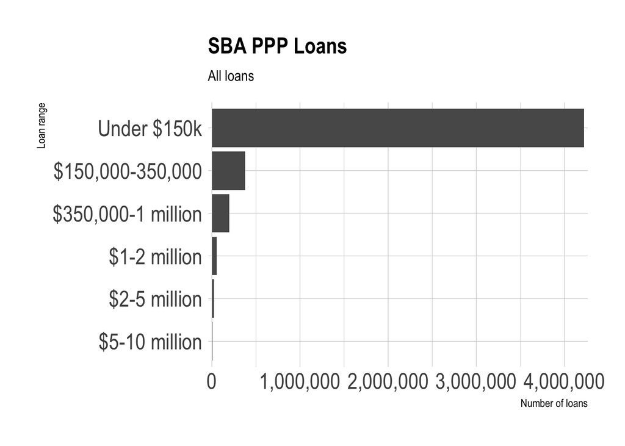

```r
ppp %>%
  count(loan_range) %>%
  mutate(loan_range = fct_reorder(loan_range, n)) %>%
  ggplot(aes(n, loan_range)) +
  geom_col() +
  labs(title = "SBA PPP Loans",
       subtitle = "All loans",
       x = "Number of loans",
       y = "Loan range") +
  scale_x_comma()
```

Loan approvals peaked in late April 2020 when the program began accepting applications for the second round, and picked up in July. There is extreme weekday-weekend seasonality in the data after April. The “U” shape from May to July generally coincides with the effort to “reopen” economies nationwide.

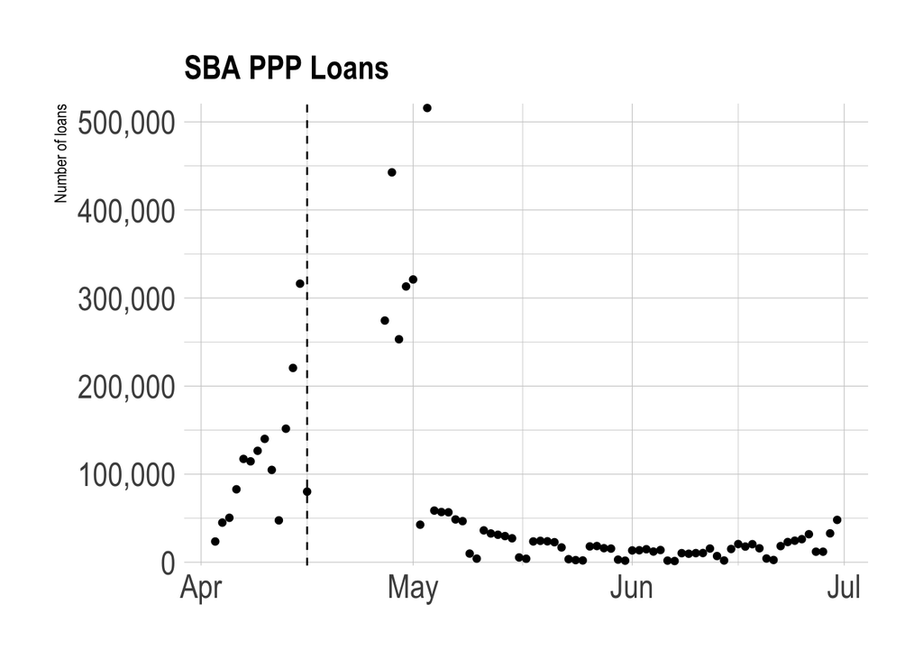

```r
ppp %>%
  count(date_approved) %>%
  ggplot(aes(date_approved, n)) +
  geom_point() +
  geom_vline(xintercept = ymd("2020-04-16"), linetype = 2) +
  labs(title = "SBA PPP Loans",
       x = NULL,
       y = "Number of loans") +
  scale_y_comma()
```

This shows that bigger loans tended to be approved earlier in the program, which was a major criticism.

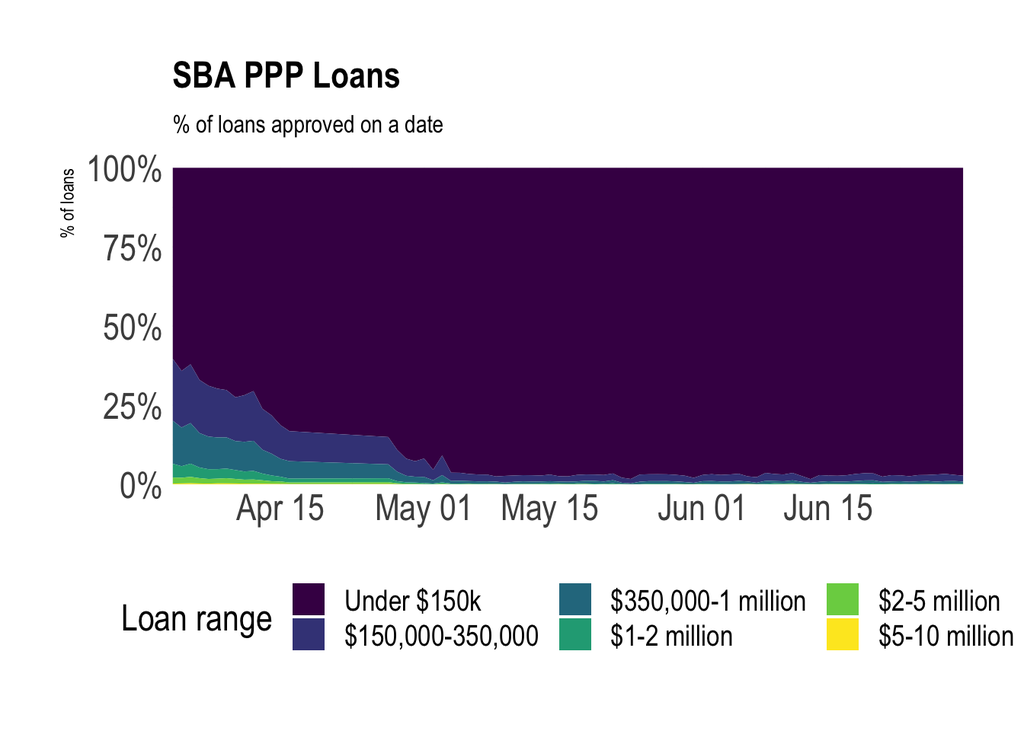

```r
ppp %>%
  count(date_approved, loan_range) %>%
  mutate(loan_range = fct_reorder(loan_range, n) %>% fct_rev) %>%
  group_by(date_approved) %>%
  mutate(pct_of_loans = n / sum(n)) %>%
  ungroup() %>%
  ggplot(aes(date_approved, pct_of_loans, fill = loan_range)) +
  geom_area() +
  scale_x_date(expand = c(0,0)) +
  scale_y_percent(expand = c(0,0)) +
  scale_fill_viridis_d() +
  labs(title = "SBA PPP Loans",
       subtitle = "% of loans approved on a date",
       x = NULL,
       y = "% of loans",
       fill = "Loan range") +
  theme(legend.position = "bottom")
```

Most states received similar proportions of small and large loans. Territories received more small loans and fewer large loans.

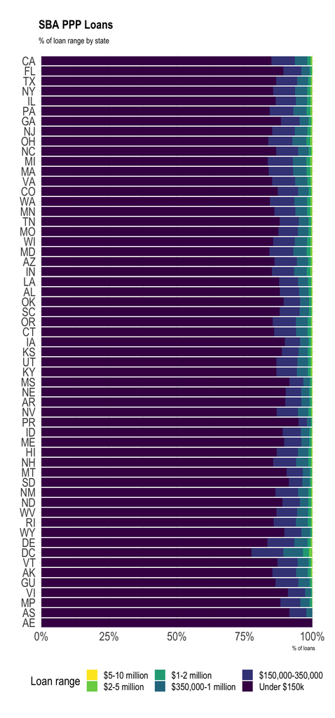

```r
ppp %>%
  mutate(loan_range = fct_inorder(loan_range)) %>%
  count(state, loan_range) %>%
  group_by(state) %>%
  mutate(pct_of_loans = n / sum(n)) %>%
  ungroup() %>%
  filter(!is.na(state)) %>%
  mutate(state = fct_reorder(state, n, .fun = sum)) %>%
  ggplot(aes(pct_of_loans, state, fill = loan_range)) +
  geom_col() +
  scale_fill_viridis_d(direction = -1) +
  scale_x_percent() +
  labs(title = "SBA PPP Loans",
       subtitle = "% of loan range by state",
       x = "% of loans",
       y = NULL,
       fill = "Loan range") +
  theme(legend.position = "bottom")
```

### Jobs

Bigger loans tended to retain more jobs.

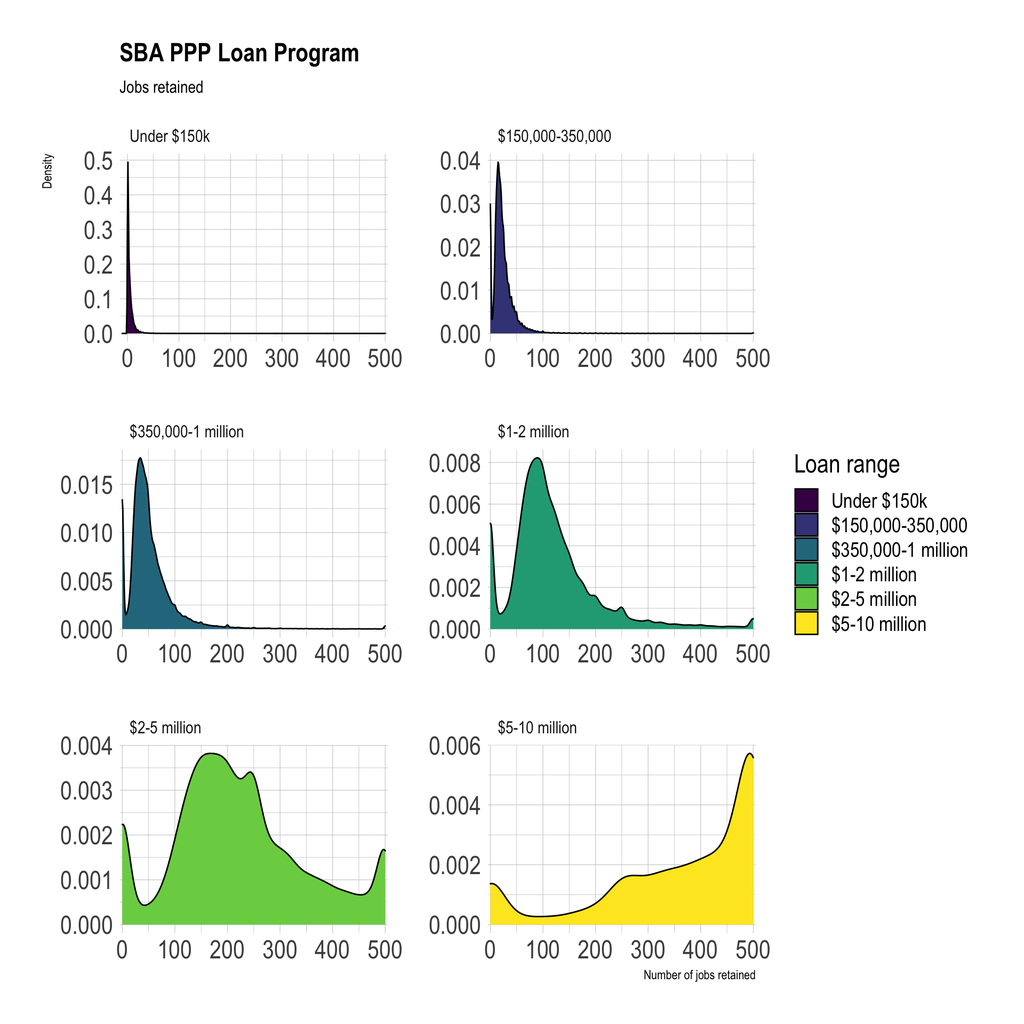

```r
ppp %>%
  filter(!is.na(jobs_retained)) %>%
  mutate(loan_range = fct_inorder(loan_range) %>% fct_rev()) %>%
  ggplot(aes(jobs_retained, fill = loan_range)) +
  #geom_histogram(bins = 200) +
  geom_density() +
  facet_wrap(~loan_range, ncol = 2, scales = "free") +
  scale_x_comma() +
  #scale_y_comma() +
  scale_fill_viridis_d() +
  labs(title = "SBA PPP Loan Program",
       subtitle = "Jobs retained",
       x = "Number of jobs retained",
       y = "Density",
       fill = "Loan range")
```

The timeline of `jobs_retained` closely matches the trend of when loans were approved.

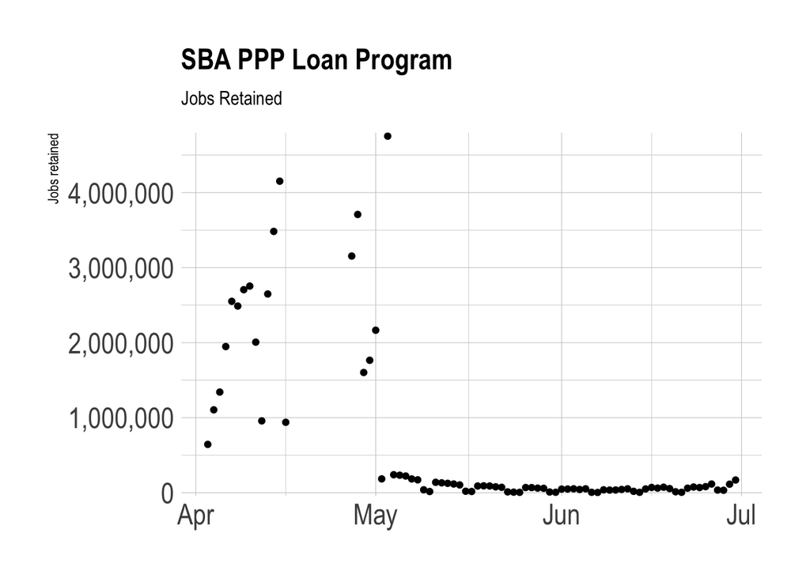

```r
ppp %>%
  filter(!is.na(jobs_retained)) %>%
  group_by(date_approved) %>%
  summarize(jobs_retained = sum(jobs_retained)) %>%
  ungroup() %>%
  ggplot(aes(date_approved, jobs_retained)) +
  geom_point() +
  scale_y_comma() +
  labs(title = "SBA PPP Loan Program",
       subtitle = "Jobs Retained",
       x = NULL,
       y = "Jobs retained")
```

Among loans less than 150k and where the data was reported, the median loan retained 6 jobs per 50k spent. Systemic reporting bias probably makes this number less reliable.

```r
ppp %>%
  filter(loan_range == "Under $150k",
         !is.na(jobs_retained),
         !is.na(loan_amount)) %>%
  select(jobs_retained, loan_amount) %>%
  mutate(jobs_retained_per_50k = (jobs_retained / loan_amount) * 50000) %>%
  summarize(jobs_retained_per_50k = median(jobs_retained_per_50k))
```

```
## # A tibble: 1 x 1
##   jobs_retained_per_50k
##                   <dbl>
## 1                  6.21
```

In the same loan range, bigger loans generally meant more jobs retained.

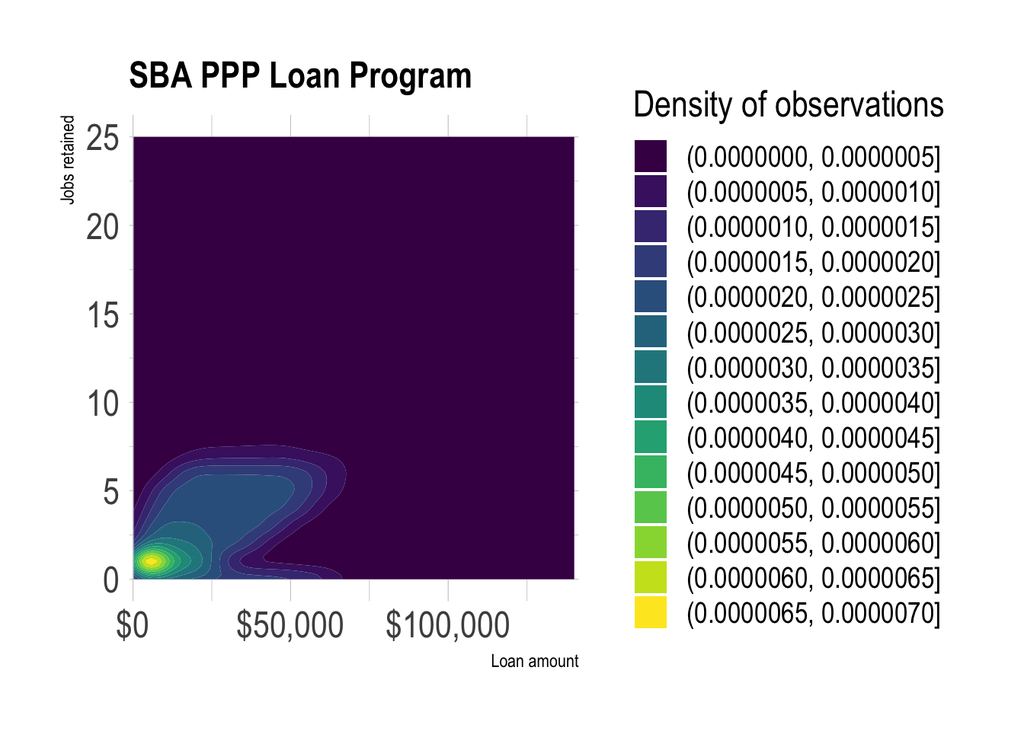

```r
test <- ppp %>%
  filter(loan_range == "Under $150k") %>%
  count(loan_amount, jobs_retained, sort = TRUE) %>%
  slice(1:5000)

test %>%
  ggplot(aes(loan_amount, jobs_retained, color = n)) +
  geom_density_2d_filled() +
  scale_x_comma(labels = scales::dollar) +
  labs(title = "SBA PPP Loan Program",
       subtitle = NULL,
       x = "Loan amount",
       y = "Jobs retained",
       fill = "Density of observations")
```

### Mapping the data

The dataset identifies which federal congressional district the applicant is from. I use `tigris` to retrieve the shapefiles for the most recent districts.

```r
congress_districts <- suppressMessages(congressional_districts(cb = TRUE, resolution = "500k", year = 2018)) %>%
  st_as_sf() %>%
  clean_names() %>%
  filter(statefp == 42)
```

This counts how many of each `loan_range` a `district` received. Note that there are missing values and what appear to be defunct district IDs in the `district` column.

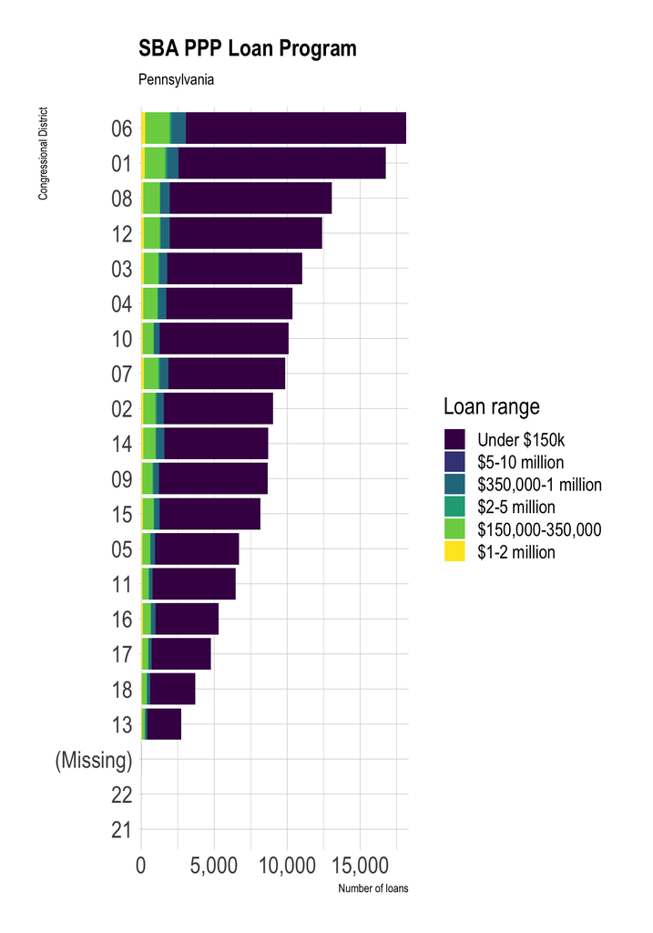

```r
ppp_pa_districts_loan_range <- ppp %>%
  filter(state == "PA") %>%
  count(district, loan_range, sort = TRUE)

ppp_pa_districts_loan_range %>%
  mutate(district = fct_explicit_na(district),
         district = fct_reorder(district, n, .fun = sum),
         loan_range = fct_rev(loan_range)) %>%
  ggplot(aes(n, district, fill = loan_range)) +
  geom_col() +
  scale_x_comma() +
  scale_fill_viridis_d() +
  labs(title = "SBA PPP Loan Program",
       subtitle = "Pennsylvania",
       x = "Number of loans",
       y = "Congressional District",
       fill =  "Loan range")
```

Districts in eastern Pennsylvania near Philadelphia received more loans from the program.

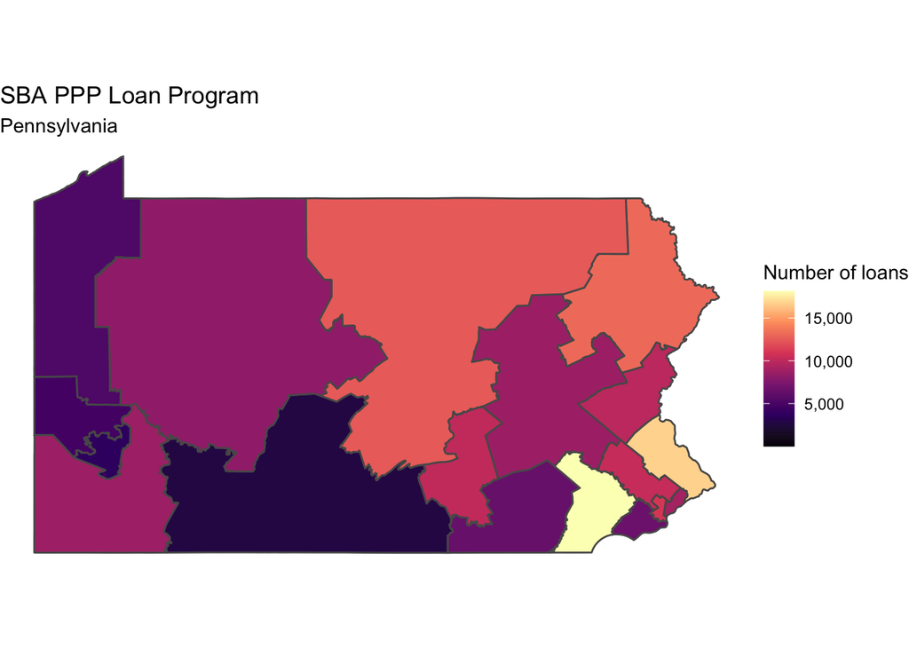

```r
ppp_pa_districts <- ppp %>%
  filter(state == "PA") %>%
  count(district, sort = TRUE)

congress_districts %>%
  right_join(ppp_pa_districts, by = c("cd116fp" = "district")) %>%
  ggplot() +
  geom_sf(aes(fill = n)) +
  scale_fill_viridis_c(option = "A", labels = scales::comma) +
  labs(title = "SBA PPP Loan Program",
       subtitle = "Pennsylvania",
       fill = "Number of loans") +
  theme_void()
```